# Are we more civilized today?

Anders Hjulmand

created 4 October 2021, updated 06 October, 2021

This exercise is based on the dataset provided by [OurWorldInDatahttps://ourworldindata.org/homicides project](https://ourworldindata.org/homicides) based at the Oxford University.

## Adeles Work

### The long-term trend in Homicides in Western Europe

Understanding how homicide rates have changed prior to the modern era requires the help of historians and archivists. Manuel Eisner, a criminology professor at the University of Cambridge, and his colleagues published the Historical Violence Database a compilation of data on long-term trends in homicide rates, in addition to qualitative information such as the cause of death, perpetrator and victim. This database is limited to countries with relatively complete historical records on violence and crime – mainly Western Europe and the US.

Starting in the second half of the nineteenth century, these European regions have consistent police records of those accused of murder or manslaughter and annual counts of homicide victims. To go back further in time, reaching as far back as the thirteenth century, Eisner collected estimates (from historical records of coroner reports, court trials, and the police) of homicide rates made in over ninety publications by scholars.5

In the chart shown here we see long-run homicide rates for the five European regions.

Homicide rates – measured as the number of homicides per 100,000 individuals – up to 1990 are sourced from Eisner’s (2003) publication and the Historical Violence Database. These estimates have been combined, from 1990 onwards, with homicide rates from the Global Burden of Disease study.6

In the 1300s, homicide rates in Western Europe ranged from 23 to 56 homicides per 100,000 individuals, comparable to the current rates in Latin America. Homicide rates then fell dramatically in all five regions from the 1300s to 1800s. The magnitude of this decline was similar across countries: homicide rates fell between 78 and 98%.

Homicide rates in Europe today are much lower than in the past. England, Germany, Switzerland, and Italy reached their lowest levels in the 2000s; while the Netherlands, Belgium, and Scandinavia reached their minimums in the mid to late 1900s.

```r
pacman::p_load(tidyverse)
```

### Load the available data from ourworldindata.org

You should always interrogate the source of your data. Who compiled it, from where, what is missing, how representative the data are? Check the data/Metadata document to learn about the data provenance.

```r
#reading the data and renaming the coloumn about homocide
Western_Europe <- read_csv("data/homicide-rates-across-western-europe.csv") %>%
  rename(homocides = 'Homicide rate in Europe over long-term (per 100,000) (homicides per 100,000 people)')
```

### Inspect the data

How clean and analysis-ready is the dataset? Do you understand what the column names represent? What is the difference between rate and homicide number?

```r
head(Western_Europe) %>%
   knitr::kable(caption = "Head of dataset")
```

Head of dataset

| Entity | Code | Year | homocides |
| --- | --- | --- | --- |
| England | NA | 1300 | 23 |
| England | NA | 1550 | 7 |
| England | NA | 1625 | 6 |
| England | NA | 1675 | 4 |
| England | NA | 1725 | 2 |
| England | NA | 1775 | 1 |

Now, that you have looked at what the data looks like and what it represents, let’s see what big picture it contains.

### Let’s see what the long-term trend is

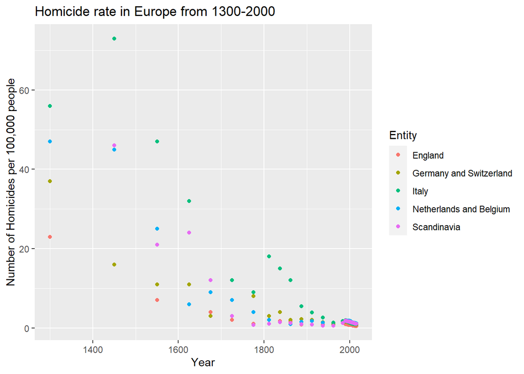

```r
ggplot(data = Western_Europe) +
  geom_point(mapping = aes(x = Year,
                           y = homocides,
                           color = Entity)) +
  labs(x = "Year",
       y = "Number of Homicides per 100,000 people",
       title = "Homicide rate in Europe from 1300-2000")
```

Alright, the homicide rates are all descending over time. What a comfort. But the viz is not super clear. Let’s check the rates for individual countries.

### Let’s uncouple for easier view of individual countries

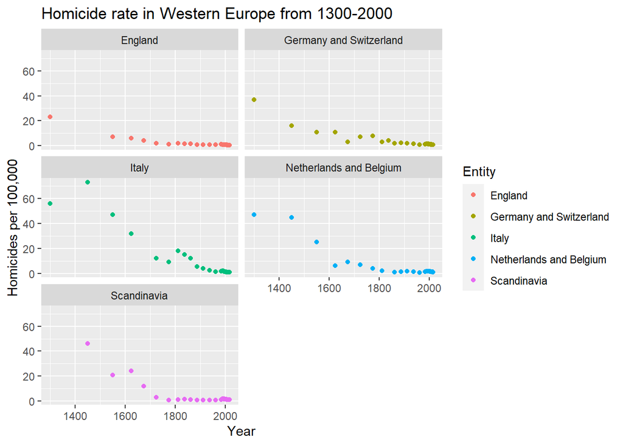

```r
ggplot(data = Western_Europe) +
  geom_point(mapping = aes(x = Year,
                           y = homocides,
                           color = Entity)) +
  facet_wrap(~ Entity, nrow = 3) +
  labs(x = "Year",
       y = "Homicides per 100,000",
       title = "Homicide rate in Western Europe from 1300-2000")
```

## Your tasks

### 1)

*the column name Western_Europe$`Homicide rate in Europe over long-term (per 100,000) is not very easy to work with. Relabel it to ‘homicides’ for easier use in the ggplots.’* I did that when loading the data.

### 2)

*The facet is great, but geom_point(scatterplot) is not the best choice for showing long-term data. Can you create other type of visualisation for a long-term trend?* I created two vizualisations using `geom_smooth` with the method `loess` and `lm`. lm just makes a straight line whereas loess allows the regression line to move and bend. I think the loess method is better at capturing the trends in the data compared to using the lm method, which just makes a straight line. E.g. using the loess moethod we can see that the development of homocides in Italy is quite different from the other countries.

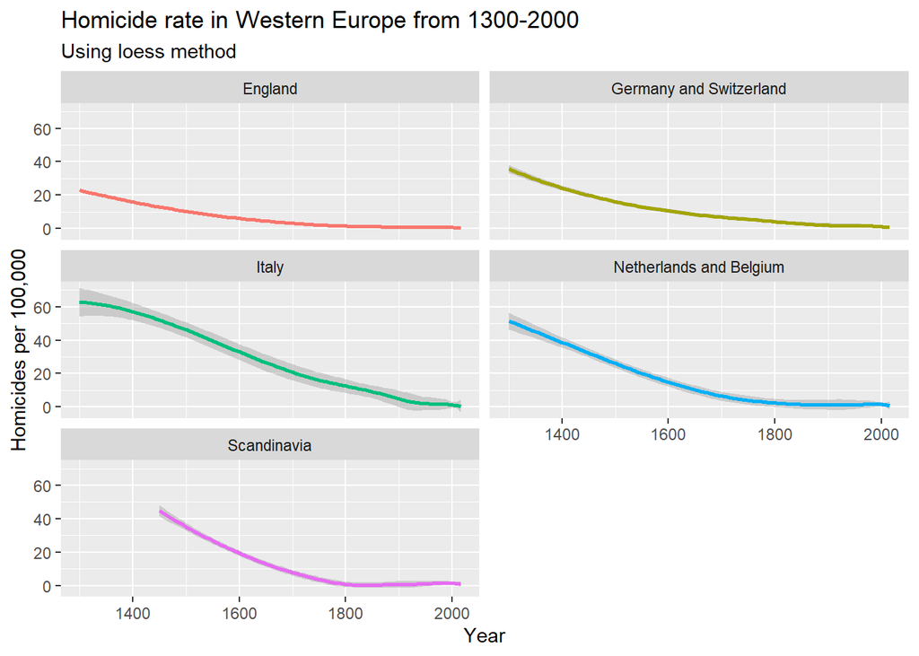

```r
#using loess method
Western_Europe %>%
  ggplot() +
  aes(Year, homocides, color = Entity) +
  geom_smooth(method = "loess") +
  facet_wrap(~Entity, nrow = 3) +
  labs(x = "Year",
       y = "Homicides per 100,000",
       title = "Homicide rate in Western Europe from 1300-2000",
       subtitle = "Using loess method") +
  theme(legend.position="none")
```

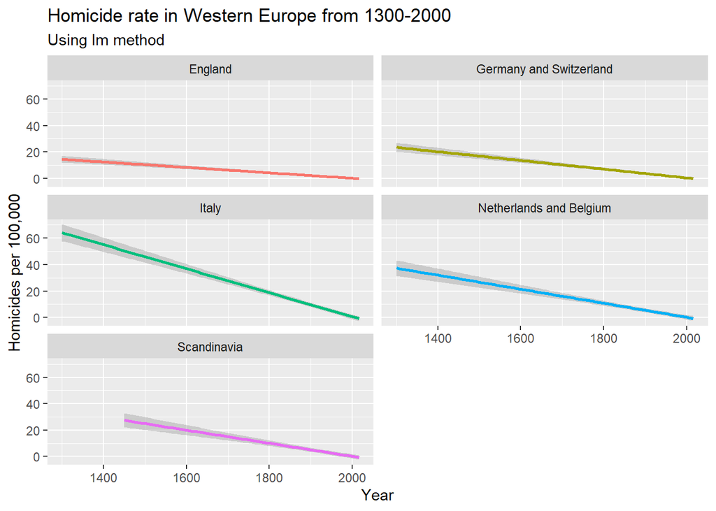

```r
#using lm method
Western_Europe %>%
  ggplot() +
  aes(Year, homocides, color = Entity) +
  geom_smooth(method = "lm") +
  facet_wrap(~Entity, nrow = 3) +
  labs(x = "Year",
       y = "Homicides per 100,000",
       title = "Homicide rate in Western Europe from 1300-2000",
       subtitle = "Using lm method") +
  theme(legend.position="none")
```

### 3)

*Can you change the facet layout to two columns and three rows so that the trends are more visible?* Hmm, i think this was already done to begin with. Or maybe i misunderstand something. But i will make the plot more readable, by changing the `fig.height` in the markdown.

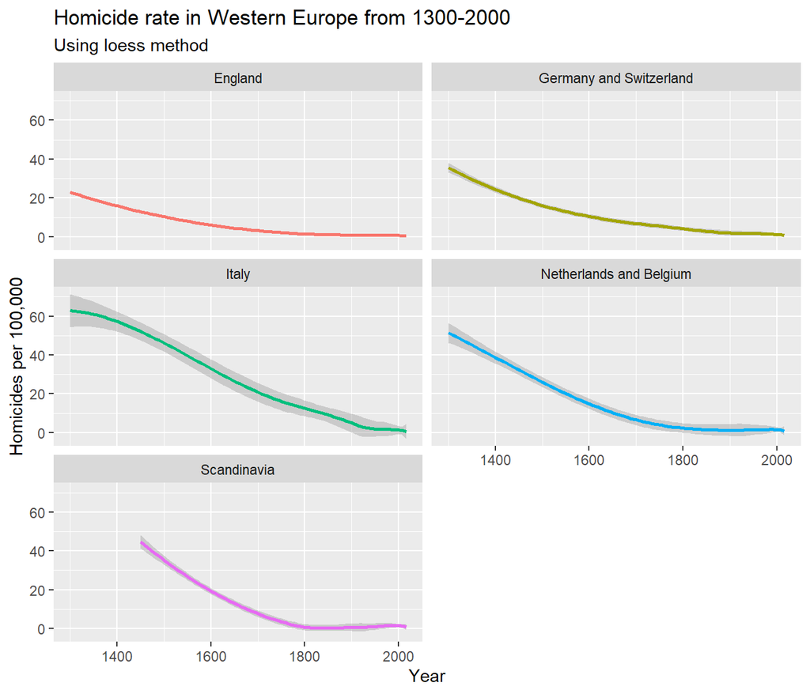

```r
Western_Europe %>%
  ggplot() +
  aes(Year, homocides, color = Entity) +
  geom_smooth(method = "loess") +
  facet_wrap(~Entity, nrow = 3) +
  labs(x = "Year",
       y = "Homicides per 100,000",
       title = "Homicide rate in Western Europe from 1300-2000",
       subtitle = "Using loess method") +
  theme(legend.position="none")
```

### 4)

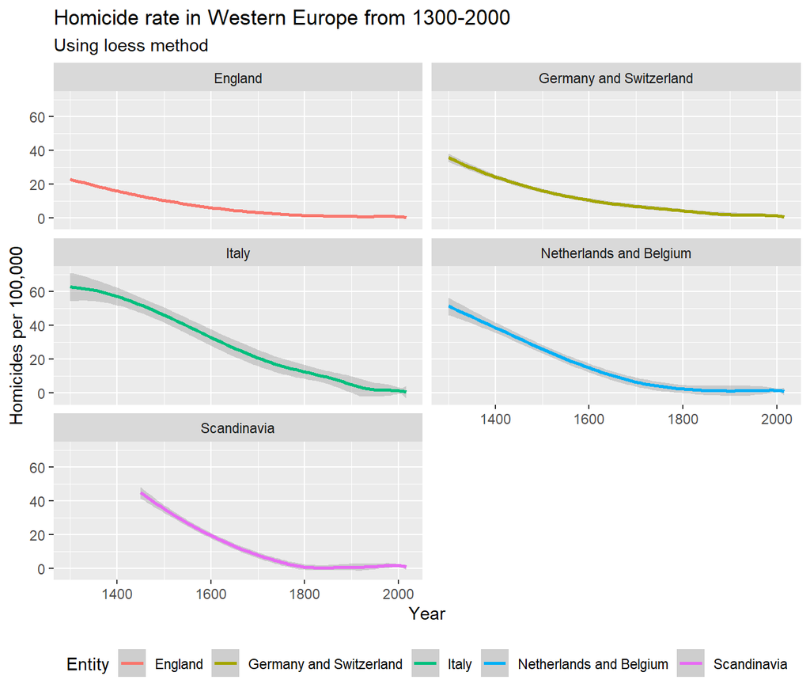

```r
Western_Europe %>%
  ggplot() +
  aes(Year, homocides, color = Entity) +
  geom_smooth(method = "loess") +
  facet_wrap(~Entity, nrow = 3) +
  labs(x = "Year",
       y = "Homicides per 100,000",
       title = "Homicide rate in Western Europe from 1300-2000",
       subtitle = "Using loess method") +
  theme(legend.position="bottom")
```

### 5)

*Add a floating table of contents to your Rmarkdown document, provide informative chunk-names to all your R chunks, and automatically generate a timestamp to show when the document was last updated.* yeye.